# Big Data Analytics

## Big Data?

[figure not shown]

[figure not shown]

Posted on flickr by BBVAtech in 2012, by Asigra [CC BY 2.0](https://creativecommons.org/licenses/by/2.0/)

## Expert Survey (UC Berkeley, 2014)

- Ask 40 experts to define *“big data”*…

## Expert Survey (UC Berkeley, 2014)

- Ask 40 experts to define *“big data”*…
- … get 40 different definitions :)

## Expert Survey (UC Berkeley, 2014)

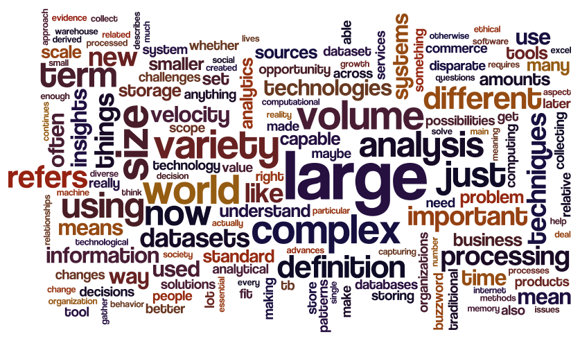

Image by Jennifer Dutcher, datascience@berkeley, source: https://datascience.berkeley.edu/what-is-big-data/

## Expert Survey: Example 1

“Big Data is the result of *collecting information at its most granular level* — it’s what you get when you instrument a system and keep all of the data that your instrumentation is able to gather.”

*Jon Bruner* (Editor-at-Large, O’Reilly Media)

## Expert Survey: Example 2

“Big data is data that contains enough observations to *demand unusual handling because of its sheer size*, though what is unusual changes over time and varies from one discipline to another.”

*Annette Greiner*  
(Lecturer, UC Berkeley School of Information)

## Expert Survey: Example 3

“[…] ‘big data’ will ultimately describe any data set large enough to necessitate *high-level programming skill* and *statistically defensible methodologies* in order to transform the data asset into something of value.”

*Reid Bryant*  
(Data Scientist, Brooks Bell)

## Conclusion

[figure not shown]

## Conclusion

- Large amounts of data (big *N*: many obs.; big *P*: many vars.)
- Various types/formats of data
- Unusual sources
- Speed of data flow/stream
- Use programming and statistics (in a broad sense) to extract value

## ‘Learn Big Data’?

[figure not shown]

‘Big Data Landscape (2019)’, source: http://mattturck.com

## Domains Affected

- How to design/set-up the machinery to handle large amounts of data? (Hardware focus, data engineering)
- How to use the existing machinery most efficiently for large amounts of data?
- How to approach the analysis of large amounts of data with econometrics?

## Focus in This Course

- How to design/set-up the machinery to handle large amounts of data? (Hardware focus, data engineering)
- *How to use the existing machinery most efficiently for large amounts of data?*
- *How to approach the analysis of large amounts of data with econometrics?*

## Focus in This Course

- How to design/set-up the machinery to handle large amounts of data? (Hardware focus, data engineering)
- *How to use the existing machinery most efficiently for large amounts of data?*
- *How to approach the analysis of large amounts of data with econometrics?*
  1. Compute ‘usual’ statistics based on large data set (many observations).

## Focus in This Course

- How to design/set-up the machinery to handle large amounts of data? (Hardware focus, data engineering)
- *How to use the existing machinery most efficiently for large amounts of data?*
- *How to approach the analysis of large amounts of data with econometrics?*
  1. Compute ‘usual’ statistics based on large data set (many observations, many variables).
  2. Practical handling of large data sets for applied econometrics (gathering, storage, preparation, etc.)

## This Course

## Four Parts

1. Setting the Scene: Analyzing Big Data (basic concepts, overview)
2. Platform: Software and Computing Resources
3. Components of Big Data Analytics (pipeline, import, cleaning, visualization)
4. Application: Topics in Big Data Econometrics

## Objectives

- Understand the *concept of Big Data* in the context of economic research.
- Understand the *technical challenges* of Big Data Analytics and how to practically deal with them.
- Know how to *apply* the relevant econometric tools, R packages and programming practices to effectively and efficiently handle large data sets.

## Schedule

## Schedule

1. *Introduction:Introduction, Big Data Econometrics. BDA book: Part I*
2. Software/Tools, Efficient R Programming. BDA book: Chapter 4
3. Hardware: Computing Resources. BDA book: Chapter 5
4. Hardware: Distributed Systems. BDA book: Chapter 6
5. Cloud Computing. BDA book: Chapter 7
6. Big Data Compilation and Storage. BDA book: Chapter 8
7. Cleaning/Preparation. BDA book: Chapter 9
8. Aggregation/Descriptives/Visualization. BDA book: Chapters 10 and 11.1-11.2
9. Visualization: GIS. BDA book: Chapter 11.3-11.4
10. Project Presentations.
11. Project Presentations; Q&A.

## Examination

- You will be working in *groups of four (or three)* and conduct a *big data analytics project*.
- You will find a *“large” data set (min. 2GB)* to work with and pose *1-2 relevant research questions*.
- You will use the techniques learned in this course to handle and analyze the large data set in order to provide *empirical answers* to your research question.
- The output of this exercise has two parts:
  1. A *technical report/“take-home exercises”*, with a detailed/structured account of the technical aspects of your project.
  2. A *short presentation* of your key findings.

## Examination: Part I

- Decentral ‐ Group examination (all given the same grades) (60%).
- Group size: 4 (or 3) students.
- “Take‐home exercises”/research report: Application of basic concepts in R when working with big data. Conceptual questions related to the application.

## Examination: Part II

- Decentral
- Group examination: presentation + code (all given the same grades) (40%)

*12 May 2022, 08:15-10:00*

*19 May 2022, 08:15-10:00*

## Approach

[figure not shown]

## Approaches to Big Data Analytics

1. *Statistics/econometrics and machine learning*: “Why not just take a random sample?!”
2. *Writing efficient code*: how can you generally speed up your analytics scripts? (scales with a lot of data)
3. *Use limited local computing resources more efficiently*: parallelization, virtual memory & co.
4. *Scale up and scale out*: distributed systems and cloud computing.

## R used in three ways

- A tool to analyze problems posed by large data sets.
  - For example, memory usage (in R).
- Illustration of underlying concepts (e.g. hardware/memory or parallelization).
- A practical tool for Big Data Analytics.

## Prerequisites?

- Basic R programming skills.
- Build on concepts taught in Data Analytics I (and more basic econometrics courses).
  - Brief review of concepts, but no additional introduction.

## Course Resources

## Literature

### Course Book

[Matter, Ulrich (2023): Big Data Analytics—A guide to data science practitioners making the transition to Big Data](https://umatter.github.io/BigData/)

## Literature

### Additional reading

[Wickham, Hadley (2019): Advanced R. Second Edition, Boca Raton, FL: CRC Press](https://adv-r.hadley.nz/)

[Wickham, Hadley and Dianne Cook and Heike Hofmann (2015): Visualizing statistical models: Removing the blindfold.Statistical Analysis and Data Mining: The ASA Data Science Journal. 8(4):203‐225.](https://onlinelibrary.wiley.com/doi/full/10.1002/sam.11271?scrollTo=references)

[Schwabish, Jonathan A. (2014): An Economistʹs Guide to Visualizing Data.Journal of Economic Perspectives. 28(1):209‐234.](https://pubs.aeaweb.org/doi/pdfplus/10.1257/jep.28.1.209)

*Lecture notes and slides will point to further reading…*

## Notes, Slides, Code, et al.

- StudyNet: slides to download, links to other resources/downloads.
- github.com/umatter/bigdata-lecture

## TODO

- [Install R](https://stat.ethz.ch/CRAN/), [RStudio](https://www.rstudio.com/products/rstudio/download/#download)
- Set up your own [GitHub](https://github.com/)-account
- [Get familiar with Git/GitHub](https://guides.github.com/activities/hello-world/)
- Create an [AWS](https://aws.amazon.com/) and [Google Cloud Platform](https://cloud.google.com) account.

## Q&A

- General questions about the course?
- Exchange students: additional information regarding prerequisites

## Big Data Econometrics

## Two broad categories

- *Big P*: high-dimensional econometrics, “too many variables” (you know this from Data Analytics I!).
- *Big N*: “too many observations”, data does not fit into memory (main focus of this course).

## A “Big P” problem

- You analyze the prepared log data from an e-commerce website.
- The aim is to come up with a useful econometric model to predict a purchase based on the user’s origin (from where was she referred to the store).
- Each user origin (domain of the previously visited site) is an explanatory variable (big P…)
- Model serves the purpose of identifying potentially important sources that should be considered in future online marketing campaigns.
- Real-life data: [Google Analytics Sample](https://console.cloud.google.com/marketplace/product/obfuscated-ga360-data/obfuscated-ga360-data?_ga=2.140068147.1003332479.1645523176-998940270.1645523176&project=onlinemedia-slant)

## The data

```r
# import/inspect data
ga <- read.csv("../data/ga.csv")
head(ga)
```

```
##   visits   source browser isMobile          city       country channelGrouping purchase
## 1      1   google  Chrome     TRUE      San Jose United States         (Other)        1
## 2      1 (direct)    Edge    FALSE     Charlotte United States          Direct        1
## 3      1 (direct)  Safari     TRUE San Francisco United States          Direct        1
## 4      1 (direct)  Safari     TRUE   Los Angeles United States          Direct        1
## 5      1 (direct)  Chrome    FALSE       Chicago United States          Direct        1
## 6      1 (direct)  Chrome    FALSE     Sunnyvale United States          Direct        1
```

## Approaches based on “traditional” econometrics

- *Any ideas?*

## Better solution: lasso estimator

- Key idea: penalize complexity of the model in order to stabilize (“regularization”).
- A lot of hypothesis testing is ‘costly’, lasso makes this cost explicit (\(\lambda\sum_k{|\beta_k|}\)).
- Provides an elegant way to get a sequence of candidate models (one for each \(\lambda\); “regularization path”).
- Procedure: first get the lasso regularization path (the candidate models sequence), then use model selection tools to choose the best model (i.e., the best \(\hat{\lambda}\))

## Lasso example: estimation

```r
# load packages
library(gamlr)

# create model matrix
mm <- model.matrix(purchase~source + browser + isMobile, data = ga)
# run K-fold cross-valudation lasso
cvpurchase <- cv.gamlr(mm, ga$purchase, family="binomial")
```

## Lasso example: prediction based on “best model”

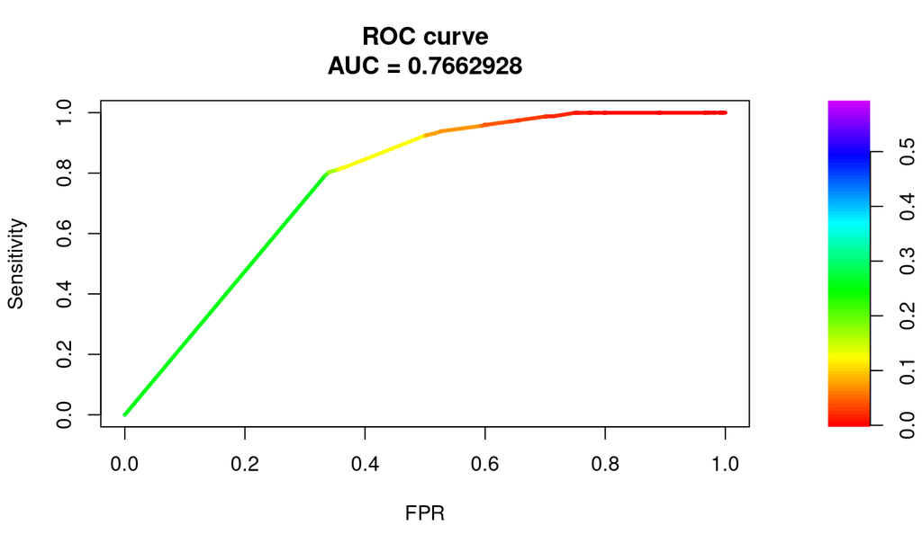

```r
# load packages
library(PRROC)

# use "best" model for prediction
# (model selection based on average OSS deviance, here CV1se rule
pred <- predict(cvpurchase$gamlr, mm, type="response")

# compute tpr, fpr, plot ROC
comparison <- roc.curve(scores.class0 = pred,
                       weights.class0=ga$purchase,
                       curve=TRUE)
plot(comparison)
```